# Tarea: Árboles y bosques aleatorios

```r
library(tidyverse)
library(ranger)
library(rpart)
library(rpart.plot)
```

Cosideramos los datos de la tarea 6:

```r
docs_tbl <- read_csv("../datos/sentiment/matriz_tarea_6.csv")
polaridad <- read_csv("../datos/sentiment/polaridad_tarea_6.csv")
names(docs_tbl) <- paste0("w", names(docs_tbl)) %>%
    make.names
docs_tbl <- mutate(docs_tbl, polaridad = pull(polaridad))
set.seed(9921)
entrena_tbl <- sample_frac(docs_tbl, 0.75)
val_tbl <- anti_join(docs_tbl, entrena_tbl)
```

## Árboles

Construimos primero un árbol podado:

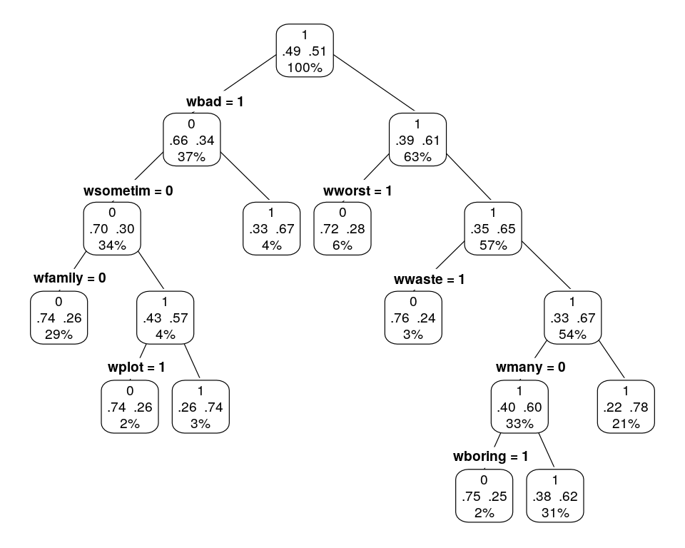

```r
arbol_grande <- rpart(polaridad ~ ., method = "class",
      data = entrena_tbl, cp = 0)
arbol_podado <- prune(arbol_grande, cp = 0.011)
prp(arbol_podado, type = 4, extra = 104,
    digits=2,  compress = FALSE, cex = 1.2)
```

**Preguntas**

1. ¿Qué significa la información que hay en cada nodo? Examina el primer nodo y cómo divide la muestra. ¿Cuáles son los nodos donde el árbol clasifica en nivel E? ¿En cuáles clasifica en AB?
2. Evalúa la tasa de clasificación correcta de entrenamiento y prueba para este árbol. Repite para el árbol completo. ¿Cómo detectas que hay sobreajuste en el árbol no podado?

```r
table(predict(arbol_podado, type = "class"), entrena_tbl$polaridad)
```

```
      0   1
  0 377 132
  1 217 485
```

```r
mean(predict(arbol_podado, type = "class") == entrena_tbl$polaridad)
```

```
[1] 0.7118084
```

```r
mean(predict(arbol_podado, newdata = val_tbl, type = "class") == val_tbl$polaridad)
```

```
[1] 0.6757426
```

```r
mean(predict(arbol_grande, type = "class") == entrena_tbl$polaridad)
```

```
[1] 0.8381503
```

```r
mean(predict(arbol_grande, newdata = val_tbl, type = "class") == val_tbl$polaridad)
```

```
[1] 0.6410891
```

3. Poda el árbol para mostrar solamente un árbol con unos 5-7 nodos terminales. ¿Qué variables son usadas? ¿Cuál es el error de entrenamiento y prueba?

[figure not shown]

```r
arbol_chico <- prune(arbol_grande, cp = 0.015)
prp(arbol_chico, type = 4, extra = 104,
    digits=2,  compress = FALSE, cex = 1.2)
```

```r
mean(predict(arbol_chico, type = "class") == entrena_tbl$polaridad)
```

```
[1] 0.6862097
```

```r
mean(predict(arbol_chico, newdata = val_tbl, type = "class") == val_tbl$polaridad)
```

```
[1] 0.6608911
```

## Bosque aleatorio

```r
bosque_docs <- ranger(polaridad ~ ., data = entrena_tbl,
       mtry = 50, min.node.size = 5, num.trees = 500,
       importance = "permutation",
       probability = TRUE)
bosque_docs
```

```
Ranger result

Call:
 ranger(polaridad ~ ., data = entrena_tbl, mtry = 50, min.node.size = 5,      num.trees = 500, importance = "permutation", probability = TRUE)

Type:                             Probability estimation
Number of trees:                  500
Sample size:                      1211
Number of independent variables:  2000
Mtry:                             50
Target node size:                 5
Variable importance mode:         permutation
Splitrule:                        gini
OOB prediction error (Brier s.):  0.189303
```

```r
bosque_docs <- ranger(polaridad ~ ., data = entrena_tbl,
       mtry = 50, min.node.size = 5, num.trees = 500,
       importance = "permutation",
       probability = TRUE)
bosque_docs
```

```
Ranger result

Call:
 ranger(polaridad ~ ., data = entrena_tbl, mtry = 50, min.node.size = 5,      num.trees = 500, importance = "permutation", probability = TRUE)

Type:                             Probability estimation
Number of trees:                  500
Sample size:                      1211
Number of independent variables:  2000
Mtry:                             50
Target node size:                 5
Variable importance mode:         permutation
Splitrule:                        gini
OOB prediction error (Brier s.):  0.1900506
```

1. ¿Qué significa la salida OOB prediction en la salida de arriba? ¿Con qué muestra se calcula esta medida de error?

OOB = out-of-bag. Para cada dato de entrenamiento, se encuentran todos los árboles que no utilizaron. Se hace votación por mayoría sobre esos árboles. En este caso, se utiliza el score de brier.

2. Calcula la matriz de confusión de prueba para el bosque. Calcula precisión y recall para cada una de las clases. Compara el error de clasificación con los árboles de la parte anterior.

```r
probs <- predict(bosque_docs, val_tbl)$predictions
head(probs)
```

```
          [,1]      [,2]
[1,] 0.4879667 0.5120333
[2,] 0.4068667 0.5931333
[3,] 0.3094000 0.6906000
[4,] 0.5094000 0.4906000
[5,] 0.4958000 0.5042000
[6,] 0.3144333 0.6855667
```

```r
tab_1 <- table(as.numeric(probs[,2] > 0.5), val_tbl$polaridad)
tab_1
```

```
      0   1
  0 159  29
  1  46 170
```

```r
mean(as.numeric(probs[,2] > 0.5) == val_tbl$polaridad)
```

```
[1] 0.8143564
```

```r
print("Recall y precisión")
```

```
[1] "Recall y precisión"
```

```r
recall_1 <- tab_1[2,2] / sum(tab_1[,2])
recall_1
```

```
[1] 0.8542714
```

```r
precision_1 <- tab_1[2,2] / sum(tab_1[2,])
precision_1
```

```
[1] 0.787037
```

3. Afina los parámetros para obtener mejor desempeño, usando el error OOB. Puedes usar el siguiente código para hacer una búsqueda aleatoria. Considerando esta corrida, adapta el grid para encontrar un mejor error:

```r
# función que ajusta un bosque y devuelve error
ajusta_bosque <- function(mtry, min.node.size, num.trees, ...){
    ajuste <- ranger(polaridad ~ ., data = entrena_tbl,
       mtry = mtry, min.node.size = min.node.size,
       num.trees = num.trees, probability = TRUE)
    # reportar error oob, puedes calcular otras cosas aquí
    ajuste$prediction.error
}
grid_params <- list(mtry = seq(1, 300, 2), min.node.size = seq(1, 50, 5),
                    num.trees = 500) %>% cross_df()
random_params <- grid_params %>% sample_n(20)
resultados_oob <- random_params %>%
    mutate(error = pmap_dbl(random_params,  ajusta_bosque))
resultados_oob
```

| mtry | min.node.size | num.trees | error |
| --- | --- | --- | --- |
| 293 | 31 | 500 | 0.1821348 |
| 117 | 41 | 500 | 0.1872911 |
| 49 | 26 | 500 | 0.1927501 |
| 77 | 21 | 500 | 0.1894176 |
| 19 | 1 | 500 | 0.1991734 |
| 19 | 21 | 500 | 0.2003528 |
| 173 | 41 | 500 | 0.1853538 |
| 163 | 21 | 500 | 0.1837681 |
| 259 | 16 | 500 | 0.1838776 |
| 281 | 41 | 500 | 0.1848848 |

[output cut: 10 more lines]

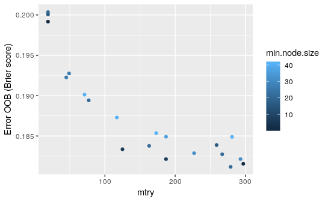

```r
ggplot(resultados_oob, aes(x = mtry, y = error, colour = min.node.size)) +
    geom_point() + ylab("Error OOB (Brier score)")
```

**Nota**:

- Nótese que estamos seleccionando parámetros usando el score de Brier out-of-bag, no la tasa de correctos.

Las simulación sugiere entonces probar:

```r
bosque_afinado <- ranger(polaridad ~ ., data = entrena_tbl,
       mtry = 150, min.node.size = 10, num.trees = 500,
       probability = TRUE)
bosque_afinado
```

```
Ranger result

Call:
 ranger(polaridad ~ ., data = entrena_tbl, mtry = 150, min.node.size = 10,      num.trees = 500, probability = TRUE)

Type:                             Probability estimation
Number of trees:                  500
Sample size:                      1211
Number of independent variables:  2000
Mtry:                             150
Target node size:                 10
Variable importance mode:         none
Splitrule:                        gini
OOB prediction error (Brier s.):  0.1826521
```

Comparamos el score de Brier de prueba de los dos bosques:

```r
probs_1 <- predict(bosque_docs, data = val_tbl)$predictions[, 2]
score_1 <- mean( (probs_1 - val_tbl$polaridad)^2)
probs_2 <- predict(bosque_afinado, data = val_tbl)$predictions[, 2]
score_2 <- mean( (probs_2 - val_tbl$polaridad)^2)
print("Primer bosque, score de Brier:")
```

```
[1] "Primer bosque, score de Brier:"
```

```r
score_1
```

```
[1] 0.1863553
```

```r
print("Bosque afinado, score de Brier:")
```

```
[1] "Bosque afinado, score de Brier:"
```

```r
score_2
```

```
[1] 0.1787365
```

el error estándar se calcula como sigue:

```r
n <- nrow(val_tbl)
sigma2_1 <- var((probs_2 - val_tbl$polaridad)^2)
sigma2_2 <- var((probs_2 - val_tbl$polaridad)^2)
ee_1 <- sqrt(sigma2_1 / n)
ee_2 <- sqrt(sigma2_1 / n)
print("bosque original:")
```

```
[1] "bosque original:"
```

```r
c(score_1 - ee_1, score_1 + ee_1) %>% round(3)
```

```
[1] 0.182 0.191
```

```r
print("bosque afinado:")
```

```
[1] "bosque afinado:"
```

```r
c(score_2 - ee_2, score_2 + ee_2) %>% round(3)
```

```
[1] 0.174 0.183
```

De forma que hay cierta evidencia de que el bosque afinado es mejor que el no afinado, en términos del score de Brier.

Ahora comparamos la tasa de correctos usando punto de corte de 0.5:

```r
correctos_1 <- mean(as.numeric(probs_1 > 0.5) == val_tbl$polaridad)
ee_1 <- sqrt(correctos_1 * (1-correctos_1) / n)
correctos_2 <- mean(as.numeric(probs_2 > 0.5) == val_tbl$polaridad)
ee_2 <- sqrt(correctos_2 * (1-correctos_2) / n)

print("tasa de correctos para bosque original:")
```

```
[1] "tasa de correctos para bosque original:"
```

```r
c(correctos_1 - ee_1, correctos_1 + ee_1) %>% round(3)
```

```
[1] 0.795 0.834
```

```r
print("tasa de correctos para bosque afinado:")
```

```
[1] "tasa de correctos para bosque afinado:"
```

```r
c(correctos_2 - ee_1, correctos_2 + ee_2) %>% round(3)
```

```
[1] 0.790 0.829
```

Sin embargo, las tasas de correctos de ambos modelos son comparables. El modelo afinado es preferible por su score de Brier más chico (discriminan mejor las probabilidades), aunque también sería necesario checar la calibración de ambos modelos.

Puedes también correr un bosque con parámetros subóptimos (por ejemplo mtry = 2) para ver cómo se contrastan dos modelos que tienen desempeño considerablemente diferente.

## Importancia de variables

**Pregunta**:

1. ¿por qué no es posible “quitar” la variable una vez que hemos construido el bosque?

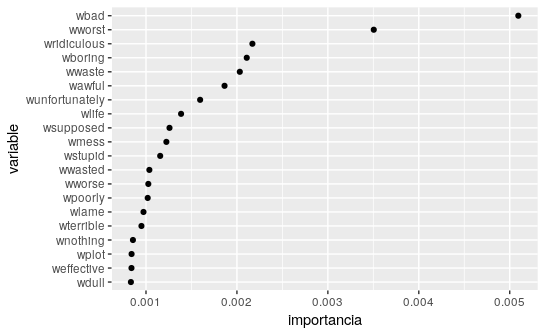

```r
imp_tbl <- tibble(importancia = bosque_docs$variable.importance,
       variable = names(bosque_docs$variable.importance)) %>%
    mutate(variable = fct_reorder(variable, importancia))
# 20 más importantes
imp_tbl_top <- imp_tbl %>% top_n(20, importancia)
ggplot(imp_tbl_top, aes(x = variable, y = importancia)) +
    coord_flip() + geom_point()
```

**Pregunta**: examina las primeras 40 variables en importancia. ¿Qué palabras positivas y negativas aparecen?